# Exploratory Graphs

## Background - perceptual tasks

Comparisons between quantitative measurements

Position vs. length

No pie charts - higher error rate compared to bar charts, easier to compare lengths than angles

- Use common scales when possible
- When possible use position comparisons
- Angle comparisons are frequently hard to interpret
- No 3D charts

```r
pData <- read.csv("./data/ss06pid.csv")
```

## Boxplots

Quantitative variables - what does distribution look like

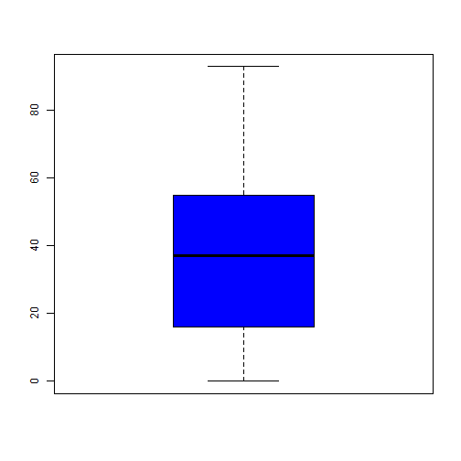

```r
boxplot(pData$AGEP, col = "blue")
```

#### plot informs whether:

- the data has a large number of values spread out or compacted
- is the distribution symmetric - where does the black line fall in the box

To make comparisons of quantitative variables on a common scale, we can use boxplots

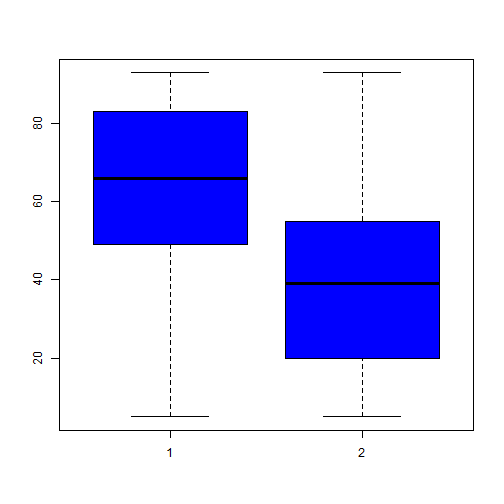

```r
boxplot(pData$AGEP ~ as.factor(pData$DDRS), col = "blue")
```

What the above boxplots don't encode is how many individuals have difficulty dressing vs. ones that don't. We can encode that with `varwidth=TRUE`

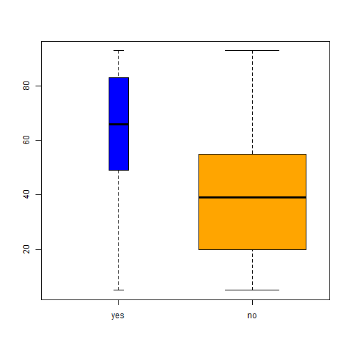

```r
boxplot(pData$AGEP ~ as.factor(pData$DDRS), col = c("blue", "orange"), names = c("yes",
    "no"), varwidth = T)
```

Width is proportional to the number of observations we have in each group.

## Barplots

position

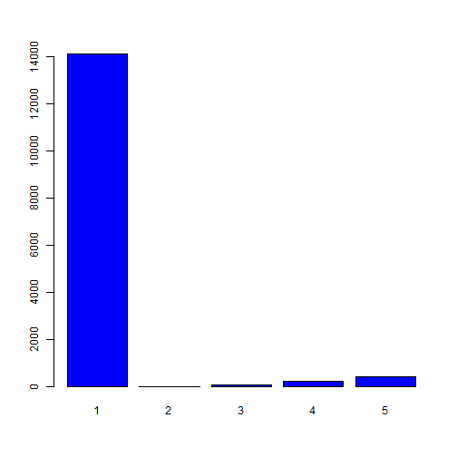

```r
barplot(table(pData$CIT), col = "blue")
```

## Histograms

frequency

- params: breaks, freq, col, xlab, ylab, xlim, _ylim, main

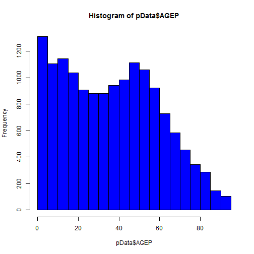

```r
hist(pData$AGEP, col = "blue")
```

You can see the shape of the distribution as opposed to boxplot.

You can set the number of breaks

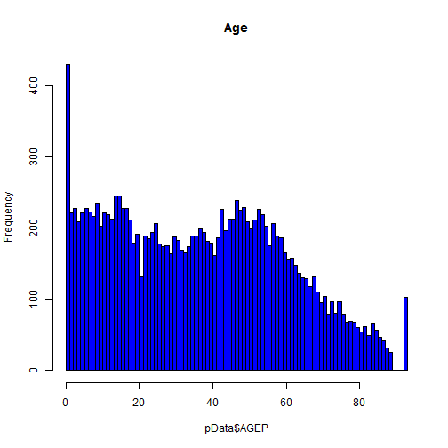

```r
hist(pData$AGEP, col = "blue", breaks = 100, main = "Age")
```

## Density plots

Like a histogram, but smoothed out

- params: col, lwd - line thickness, xlab, ylab, xlim, ylim

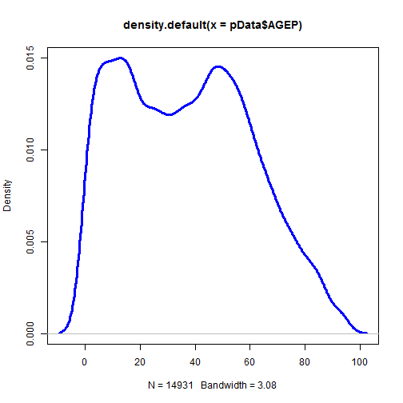

```r
dens <- density(pData$AGEP)
plot(dens, lwd = 3, col = "blue")
```

Density is different from frequency in that it shows the percentage of the observations between 0 and 1. Smoothing introduces error

You can overlay distributions for different, say, genders

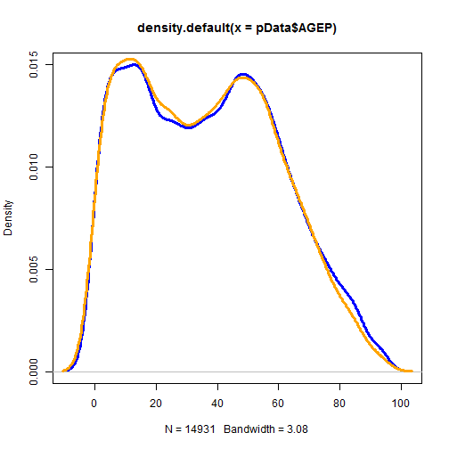

```r
densMales <- density(pData$AGEP[which(pData$SEX == 1)])
plot(dens, lwd = 3, col = "blue")
lines(densMales, lwd = 3, col = "orange")
```

## Scatterplots

Visualize relationships between variables

- vars:
  - x, y - points, same length
  - type
  - xlab, ylab - variable labels
  - xlim, ylim - limites
  - cex - size of points,
  - col - color of point
  - bg - background of points for specific type of points
  - pch - type of point `?par`

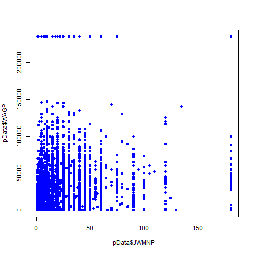

```r
plot(pData$JWMNP, pData$WAGP, pch = 19, col = "blue")
```

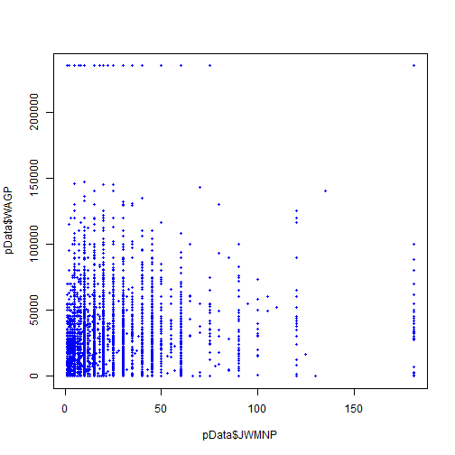

```r
plot(pData$JWMNP, pData$WAGP, pch = 19, col = "blue", cex = 0.5)
```

Encodes color by sex

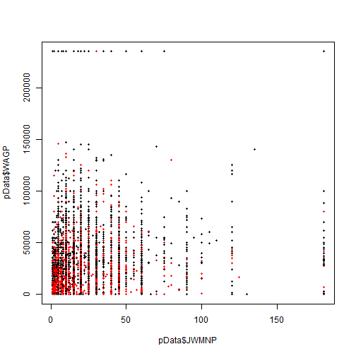

```r
plot(pData$JWMNP, pData$WAGP, pch = 19, col = pData$SEX, cex = 0.5)
```

Using size

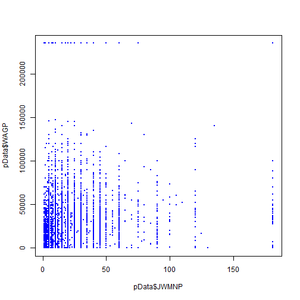

```r
percentMaxAge <- pData$AGEP/max(pData$AGEP)
plot(pData$JWMNP, pData$WAGP, pch = 19, col = "blue", cex = percentMaxAge *
    0.5)
```

overlaying lines/points

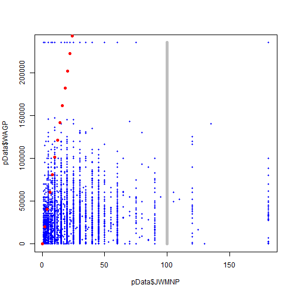

```r
plot(pData$JWMNP, pData$WAGP, pch = 19, col = "blue", cex = 0.5)
lines(rep(100, dim(pData)[1]), pData$WAGP, col = "grey", lwd = 5)
points(seq(0, 200, length = 100), seq(0, 2e+06, length = 100), col = "red",
    pch = 19)
```

numeric variables as factors

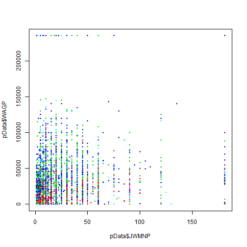

```r
library(Hmisc)
ageGroups <- cut2(pData$AGEP, g = 5)
plot(pData$JWMNP, pData$WAGP, pch = 19, col = ageGroups, cex = 0.5)
```

It doesn't look like there's a difference in distributions across ages for this data.

If there's a lot of points

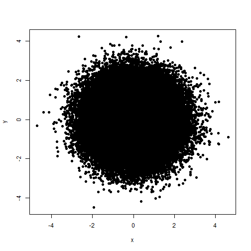

```r
x <- rnorm(1e+05)
y <- rnorm(1e+05)
plot(x, y, pch = 19)
```

The plot may not be informative. To fix:

sampling

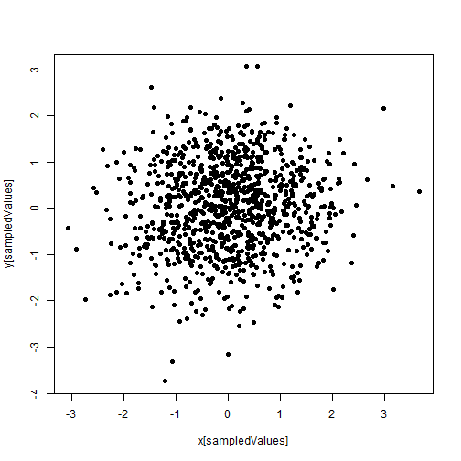

```r
x <- rnorm(1e+05)
y <- rnorm(1e+05)
sampledValues <- sample(1:1e+05, size = 1000, replace = FALSE)
plot(x[sampledValues], y[sampledValues], pch = 19)
```

smooth scatter - smooth density plot

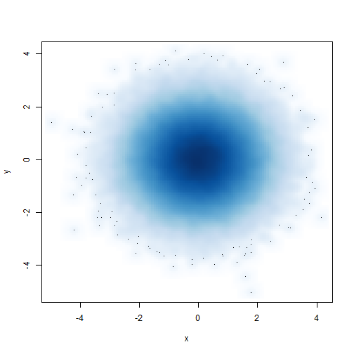

```r
x <- rnorm(1e+05)
y <- rnorm(1e+05)
smoothScatter(x, y)
```

outline points are hard dots

hexbin

```r
x <- rnorm(1e+05)
y <- rnorm(1e+05)
hbo <- hexbin(x, y)
```

[output not shown]

```
## Error: could not find function "hexbin"
```

```r
plot(hbo)
```

[output not shown]

```
## Error: object 'hbo' not found
```